```r
##              Length Class  Mode
## cluster      25     -none- numeric
## centers      45     -none- numeric
## totss         1     -none- numeric
## withinss      5     -none- numeric
## tot.withinss  1     -none- numeric
## betweenss     1     -none- numeric
## size          5     -none- numeric
## iter          1     -none- numeric
## ifault        1     -none- numeric

pclusters$centers                                                       # Note: 3
```

```
##        RedMeat  WhiteMeat        Eggs       Milk       Fish    Cereals
## 1 -0.570049402  0.5803879 -0.08589708 -0.4604938 -0.4537795  0.3181839
## 2 -0.807569986 -0.8719354 -1.55330561 -1.0783324 -1.0386379  1.7200335
## 3  0.006572897 -0.2290150  0.19147892  1.3458748  1.1582546 -0.8722721
## 4  1.011180399  0.7421332  0.94084150  0.5700581 -0.2671539 -0.6877583
## 5 -0.508801956 -1.1088009 -0.41248496 -0.8320414  0.9819154  0.1300253
##       Starch       Nuts      Fr.Veg
## 1  0.7857609 -0.2679180  0.06873983
## 2 -1.4234267  0.9961313 -0.64360439
## 3  0.1676780 -0.9553392 -1.11480485
## 4  0.2288743 -0.5083895  0.02161979
## 5 -0.1842010  1.3108846  1.62924487
```

```r
##        RedMeat  WhiteMeat        Eggs       Milk       Fish    Cereals
## 1 -0.570049402  0.5803879 -0.08589708 -0.4604938 -0.4537795  0.3181839
## 2 -0.508801956 -1.1088009 -0.41248496 -0.8320414  0.9819154  0.1300253
## 3 -0.807569986 -0.8719354 -1.55330561 -1.0783324 -1.0386379  1.7200335
## 4  0.006572897 -0.2290150  0.19147892  1.3458748  1.1582546 -0.8722721
## 5  1.011180399  0.7421332  0.94084150  0.5700581 -0.2671539 -0.6877583
##       Starch       Nuts      Fr.Veg
## 1  0.7857609 -0.2679180  0.06873983
## 2 -0.1842010  1.3108846  1.62924487
## 3 -1.4234267  0.9961313 -0.64360439
## 4  0.1676780 -0.9553392 -1.11480485
## 5  0.2288743 -0.5083895  0.02161979

pclusters$size                                                          # Note: 4
```

```
## [1] 5 4 4 8 4
```

```r
## [1] 5 4 4 4 8

groups <- pclusters$cluster                                             # Note: 5

cols_to_print = wrapr::qc(Country, RedMeat, Fish, Fr.Veg)
print_clusters(protein, groups, cols_to_print)                                          # Note: 6
```

```
## $`1`
##           Country RedMeat Fish Fr.Veg
## 5  Czechoslovakia     9.7  2.0    4.0
## 7       E Germany     8.4  5.4    3.6
## 11        Hungary     5.3  0.3    4.2
## 16         Poland     6.9  3.0    6.6
## 23           USSR     9.3  3.0    2.9
##
## $`2`
##       Country RedMeat Fish Fr.Veg
## 1     Albania    10.1  0.2    1.7
## 4    Bulgaria     7.8  1.2    4.2
## 18    Romania     6.2  1.0    2.8
## 25 Yugoslavia     4.4  0.6    3.2
##
## $`3`
##    Country RedMeat Fish Fr.Veg
## 6  Denmark    10.6  9.9    2.4
## 8  Finland     9.5  5.8    1.4
## 15  Norway     9.4  9.7    2.7
## 20  Sweden     9.9  7.5    2.0
##
## $`4`
##        Country RedMeat Fish Fr.Veg
## 2      Austria     8.9  2.1    4.3
## 3      Belgium    13.5  4.5    4.0
## 9       France    18.0  5.7    6.5
## 12     Ireland    13.9  2.2    2.9
## 14 Netherlands     9.5  2.5    3.7
## 21 Switzerland    13.1  2.3    4.9
## 22          UK    17.4  4.3    3.3
## 24   W Germany    11.4  3.4    3.8
##
## $`5`
##     Country RedMeat Fish Fr.Veg
## 10   Greece    10.2  5.9    6.5
## 13    Italy     9.0  3.4    6.7
## 17 Portugal     6.2 14.2    7.9
## 19    Spain     7.1  7.0    7.2
```

```r
## $`1`
##           Country RedMeat Fish Fr.Veg
## 5  Czechoslovakia     9.7  2.0    4.0
## 7       E Germany     8.4  5.4    3.6
## 11        Hungary     5.3  0.3    4.2
## 16         Poland     6.9  3.0    6.6
## 23           USSR     9.3  3.0    2.9
##
## $`2`
##     Country RedMeat Fish Fr.Veg
## 10   Greece    10.2  5.9    6.5
## 13    Italy     9.0  3.4    6.7
## 17 Portugal     6.2 14.2    7.9
## 19    Spain     7.1  7.0    7.2
##
## $`3`
##       Country RedMeat Fish Fr.Veg
## 1     Albania    10.1  0.2    1.7
## 4    Bulgaria     7.8  1.2    4.2
## 18    Romania     6.2  1.0    2.8
## 25 Yugoslavia     4.4  0.6    3.2
##
## $`4`
##    Country RedMeat Fish Fr.Veg
## 6  Denmark    10.6  9.9    2.4
## 8  Finland     9.5  5.8    1.4
## 15  Norway     9.4  9.7    2.7
## 20  Sweden     9.9  7.5    2.0
##
## $`5`
##        Country RedMeat Fish Fr.Veg
## 2      Austria     8.9  2.1    4.3
## 3      Belgium    13.5  4.5    4.0
## 9       France    18.0  5.7    6.5
## 12     Ireland    13.9  2.2    2.9
## 14 Netherlands     9.5  2.5    3.7
## 21 Switzerland    13.1  2.3    4.9
## 22          UK    17.4  4.3    3.3
## 24   W Germany    11.4  3.4    3.8

# Note 1:
#   Run kmeans() with five clusters (kbest_p=5),
#   100 random starts, and 100 maximum iterations per
#   run.

# Note 2:
#   kmeans() returns all the sum of squares
#   measures.

# Note 3:
#   pclusters$centers is a matrix whose rows are
#   the centroids of the clusters. Note that
#   pclusters$centers is in the scaled coordinates,
#   not the original protein coordinates.

# Note 4:
#   pclusters$size returns the number of points
#   in each cluster. Generally (though not always) a
#   good clustering will be fairly well balanced: no
#   extremely small clusters and no extremely large
#   ones.

# Note 5:
#   pclusters$cluster is a vector of cluster
#   labels.

# Note 6:
#   In this case, kmeans() and hclust() returned
#   the same clustering. This won’t always be true.
```

00382_example_9.12_of_section_9.1.4.R

```r
# example 9.12 of section 9.1.4
# (example 9.12 of section 9.1.4)  : Unsupervised methods : Cluster analysis : The k-means algorithm
# Title: Plotting cluster criteria

clustering_ch <- kmeansruns(pmatrix, krange=1:10, criterion="ch")           # Note: 1
clustering_ch$bestk                                                     # Note: 2
```

```
## [1] 2
```

```r
## [1] 2

clustering_asw <- kmeansruns(pmatrix, krange=1:10, criterion="asw")         # Note: 3
clustering_asw$bestk
```

```
## [1] 3
```

```r
## [1] 3

clustering_asw$crit                                                     # Note: 4
```

```
##  [1] 0.0000000 0.3271084 0.3351694 0.2617868 0.2639450 0.2734815 0.2471165
##  [8] 0.2429985 0.2412922 0.2388293
```

```r
## [1] 0.0000000 0.3271084 0.3351694 0.2617868 0.2639450 0.2734815 0.2471165
## [8] 0.2429985 0.2412922 0.2388293

clustering_ch$crit                                                      # Note: 5
```

```
##  [1]  0.000000 14.094814 11.417985 10.418801 10.011797  9.964967  9.861682
##  [8]  9.412089  9.166676  9.075569
```

```r
##  [1]  0.000000 14.094814 11.417985 10.418801 10.011797  9.964967  9.861682
##  [8]  9.412089  9.166676  9.075569

cluster_meas$ch_crit                                                            # Note: 6
```

```
##  [1]       NaN 12.215107 10.359587  9.690891 10.011797  9.964967  9.506978
##  [8]  9.092065  8.822406  8.695065
```

```r
##  [1]       NaN 12.215107 10.359587  9.690891 10.011797  9.964967  9.506978
##  [8]  9.092065  8.822406  8.695065


summary(clustering_ch)                                                  # Note: 7
```

```
##              Length Class  Mode
## cluster      25     -none- numeric
## centers      18     -none- numeric
## totss         1     -none- numeric
## withinss      2     -none- numeric
## tot.withinss  1     -none- numeric
## betweenss     1     -none- numeric
## size          2     -none- numeric
## iter          1     -none- numeric
## ifault        1     -none- numeric
## crit         10     -none- numeric
## bestk         1     -none- numeric
```

```r
##              Length Class  Mode
## cluster      25     -none- numeric
## centers      18     -none- numeric
## totss         1     -none- numeric
## withinss      2     -none- numeric
## tot.withinss  1     -none- numeric
## betweenss     1     -none- numeric
## size          2     -none- numeric
## iter          1     -none- numeric
## ifault        1     -none- numeric
## crit         10     -none- numeric
## bestk         1     -none- numeric

# Note 1:
#   Run kmeansruns() from 1–10 clusters, and the
#   CH criterion. By default, kmeansruns() uses 100
#   random starts and 100 maximum iterations per
#   run.

# Note 2:
#   The CH criterion picks two clusters.

# Note 3:
#   Run kmeansruns() from 1–10 clusters, and the
#   average silhouette width criterion. Average
#   silhouette width picks 3 clusters.

# Note 4:
#   Look at the values of the asw criterion as a function of k.

# Note 5:
#   Look at the values of the CH criterion as a function of k.

# Note 6:
#   Compare the above to the CH values for the
#   hclust() clustering. They’re not quite the same, because the
#   two algorithms didn’t pick the same clusters.

# Note 7:
#   kmeansruns() also returns the output of
#   kmeans for k=bestk.
```

00383_example_9.13_of_section_9.1.4.R

```r
# example 9.13 of section 9.1.4
# (example 9.13 of section 9.1.4)  : Unsupervised methods : Cluster analysis : The k-means algorithm
# Title: Running clusterboot() with k-means

kbest_p <- 5
cboot <- clusterboot(pmatrix, clustermethod=kmeansCBI,
            runs=100,iter.max=100,
            krange=kbest_p, seed=15555)                 # Note: 1
```

[output not shown]

[output cut: 45 more lines]

[output not shown]

```r
groups <- cboot$result$partition
print_clusters(protein, groups, cols_to_print)
```

```
## $`1`
##       Country RedMeat Fish Fr.Veg
## 1     Albania    10.1  0.2    1.7
## 4    Bulgaria     7.8  1.2    4.2
## 18    Romania     6.2  1.0    2.8
## 25 Yugoslavia     4.4  0.6    3.2
##
## $`2`
##    Country RedMeat Fish Fr.Veg
## 6  Denmark    10.6  9.9    2.4
## 8  Finland     9.5  5.8    1.4
## 15  Norway     9.4  9.7    2.7
## 20  Sweden     9.9  7.5    2.0
##
## $`3`
##           Country RedMeat Fish Fr.Veg
## 5  Czechoslovakia     9.7  2.0    4.0
## 7       E Germany     8.4  5.4    3.6
## 11        Hungary     5.3  0.3    4.2
## 16         Poland     6.9  3.0    6.6
## 23           USSR     9.3  3.0    2.9
##
## $`4`
##        Country RedMeat Fish Fr.Veg
## 2      Austria     8.9  2.1    4.3
## 3      Belgium    13.5  4.5    4.0
## 9       France    18.0  5.7    6.5
## 12     Ireland    13.9  2.2    2.9
## 14 Netherlands     9.5  2.5    3.7
## 21 Switzerland    13.1  2.3    4.9
## 22          UK    17.4  4.3    3.3
## 24   W Germany    11.4  3.4    3.8
##
## $`5`
##     Country RedMeat Fish Fr.Veg
## 10   Greece    10.2  5.9    6.5
## 13    Italy     9.0  3.4    6.7
## 17 Portugal     6.2 14.2    7.9
## 19    Spain     7.1  7.0    7.2
```

```r
## $`1`
##       Country RedMeat Fish Fr.Veg
## 1     Albania    10.1  0.2    1.7
## 4    Bulgaria     7.8  1.2    4.2
## 18    Romania     6.2  1.0    2.8
## 25 Yugoslavia     4.4  0.6    3.2
##
## $`2`
##    Country RedMeat Fish Fr.Veg
## 6  Denmark    10.6  9.9    2.4
## 8  Finland     9.5  5.8    1.4
## 15  Norway     9.4  9.7    2.7
## 20  Sweden     9.9  7.5    2.0
##
## $`3`
##           Country RedMeat Fish Fr.Veg
## 5  Czechoslovakia     9.7  2.0    4.0
## 7       E Germany     8.4  5.4    3.6
## 11        Hungary     5.3  0.3    4.2
## 16         Poland     6.9  3.0    6.6
## 23           USSR     9.3  3.0    2.9
##
## $`4`
##        Country RedMeat Fish Fr.Veg
## 2      Austria     8.9  2.1    4.3
## 3      Belgium    13.5  4.5    4.0
## 9       France    18.0  5.7    6.5
## 12     Ireland    13.9  2.2    2.9
## 14 Netherlands     9.5  2.5    3.7
## 21 Switzerland    13.1  2.3    4.9
## 22          UK    17.4  4.3    3.3
## 24   W Germany    11.4  3.4    3.8
##
## $`5`
##     Country RedMeat Fish Fr.Veg
## 10   Greece    10.2  5.9    6.5
## 13    Italy     9.0  3.4    6.7
## 17 Portugal     6.2 14.2    7.9
## 19    Spain     7.1  7.0    7.2

cboot$bootmean
```

```
## [1] 0.8670000 0.8420714 0.6147024 0.7647341 0.7508333
```

```r
## [1] 0.8670000 0.8420714 0.6147024 0.7647341 0.7508333

cboot$bootbrd
```

```
## [1] 15 20 49 17 32
```

```r
## [1] 15 20 49 17 32

# Note 1:
#   We’ve set the seed for the random generator
#   so the results are reproducible.
```

00384_example_9.14_of_section_9.1.5.R

```r
# example 9.14 of section 9.1.5
# (example 9.14 of section 9.1.5)  : Unsupervised methods : Cluster analysis : Assigning new points to clusters
# Title: A function to assign points to a cluster

assign_cluster <- function(newpt, centers, xcenter=0, xscale=1) {
   xpt <- (newpt - xcenter)/xscale                                  # Note: 1
   dists <- apply(centers, 1, FUN=function(c0){sqr_edist(c0, xpt)})     # Note: 2
   which.min(dists)                                                     # Note: 3
 }

# Note 1:
#   Center and scale the new data point.

# Note 2:
#   Calculate how far the new data point is from
#   each of the cluster centers.

# Note 3:
#   Return the cluster number of the closest
#   centroid.
```

00385_example_9.15_of_section_9.1.5.R

```r
# example 9.15 of section 9.1.5
# (example 9.15 of section 9.1.5)  : Unsupervised methods : Cluster analysis : Assigning new points to clusters
# Title: Generate and cluster synthetic data for cluster assignment example

mean1 <- c(1, 1, 1)                         # Note: 1
sd1 <- c(1, 2, 1)

mean2 <- c(10, -3, 5)
sd2 <- c(2, 1, 2)

mean3 <- c(-5, -5, -5)
sd3 <- c(1.5, 2, 1)

library(MASS)                                   # Note: 2
clust1 <- mvrnorm(100, mu=mean1, Sigma=diag(sd1))
clust2 <- mvrnorm(100, mu=mean2, Sigma=diag(sd2))
clust3 <- mvrnorm(100, mu=mean3, Sigma=diag(sd3))
toydata <- rbind(clust3, rbind(clust1, clust2))

tmatrix <- scale(toydata)                           # Note: 3
tcenter <- attr(tmatrix, "scaled:center")               # Note: 4
tscale <-attr(tmatrix, "scaled:scale")
tmatrix <- rm_scales(tmatrix)

kbest_t <- 3
tclusters <- kmeans(tmatrix, kbest_t, nstart=100, iter.max=100)         # Note: 5

tclusters$size              # Note: 6
```

```
## [1] 101 100  99
```

```r
## [1] 101 100  99

# Note 1:
#   Set the parameters for three 3-D gaussian clusters.

# Note 2:
#   Use the mvrnorm() function from MASS package to generate
#   three dimensional axis-aligned gaussian clusters.

# Note 3:
#   Scale the synthetic data.

# Note 4:
#   Get the scaling attributes, then remove them from the matrix.

# Note 5:
#   Cluster the synthetic data into three clusters.

# Note 6:
#   The generated clusters are consistent in size with the true clusters.
```

00386_example_9.16_of_section_9.1.5.R

```r
# example 9.16 of section 9.1.5
# (example 9.16 of section 9.1.5)  : Unsupervised methods : Cluster analysis : Assigning new points to clusters
# Title: Unscale the centers

unscaled = scale(tclusters$centers, center=FALSE, scale=1/tscale)
rm_scales(scale(unscaled, center = -tcenter, scale=FALSE))
```

```
##         [,1]      [,2]       [,3]
## 1  9.8234797 -3.005977  4.7662651
## 2 -4.9749654 -4.862436 -5.0577002
## 3  0.8926698  1.185734  0.8336977
```

```r
##         [,1]      [,2]       [,3]
## 1  9.8234797 -3.005977  4.7662651
## 2 -4.9749654 -4.862436 -5.0577002
## 3  0.8926698  1.185734  0.8336977
```

00387_example_9.17_of_section_9.1.5.R

```r
# example 9.17 of section 9.1.5
# (example 9.17 of section 9.1.5)  : Unsupervised methods : Cluster analysis : Assigning new points to clusters
# Title: An example of assigning points to clusters

assign_cluster(mvrnorm(1, mean1, diag(sd1)),        # Note: 1
                tclusters$centers,
                tcenter, tscale)
```

```
## 3
## 3
```

```r
## 3
## 3

assign_cluster(mvrnorm(1, mean2, diag(sd2)),        # Note: 2
                tclusters$centers,
                tcenter, tscale)
```

```
## 1
## 1
```

```r
## 1
## 1

assign_cluster(mvrnorm(1, mean3, diag(sd3)),            # Note: 3
                tclusters$centers,
                tcenter, tscale)
```

```
## 2
## 2
```

```r
## 2
## 2

# Note 1:
#   # This should be assigned to cluster 3.

# Note 2:
#   # This should be assigned to cluster 1.

# Note 3:
#   # This should be assigned to cluster 2.
```

00389_example_9.18_of_section_9.2.3.R

```r
# example 9.18 of section 9.2.3
# (example 9.18 of section 9.2.3)  : Unsupervised methods : Association rules : Mining association rules with the arules package
# Title: Reading in the book data

library(arules)     # Note: 1
bookbaskets <- read.transactions("../Bookdata/bookdata.tsv.gz",
                                     format="single",   # Note: 2
                                     header=TRUE,       # Note: 3
                                     sep="\t",                      # Note: 4
                                     cols=c("userid", "title"),     # Note: 5
                                     rm.duplicates=TRUE)        # Note: 6

# Note 1:
#   Load the arules package.

# Note 2:
#   Specify the file and the file format.

# Note 3:
#   Specify that the input file has a header.

# Note 4:
#   Specify the column separator (a tab).

# Note 5:
#   Specify the column of transaction IDs and of
#   item IDs, respectively.

# Note 6:
#   Tell the function to look for and remove
#   duplicate entries (for example, multiple entries
#   for “The Hobbit” by the same user).
```

00390_example_9.19_of_section_9.2.3.R

```r
# example 9.19 of section 9.2.3
# (example 9.19 of section 9.2.3)  : Unsupervised methods : Association rules : Mining association rules with the arules package
# Title: Examining the transaction data

class(bookbaskets)              # Note: 1
```

```
## [1] "transactions"
## attr(,"package")
## [1] "arules"
```

```r
## [1] "transactions"
## attr(,"package")
## [1] "arules"
bookbaskets                     # Note: 2
```

```
## transactions in sparse format with
##  92108 transactions (rows) and
##  220447 items (columns)
```

```r
## transactions in sparse format with
##  92108 transactions (rows) and
##  220447 items (columns)
dim(bookbaskets)                # Note: 3
```

```
## [1]  92108 220447
```

```r
## [1]  92108 220447
colnames(bookbaskets)[1:5]      # Note: 4
```

```
## [1] " A Light in the Storm: The Civil War Diary of Amelia Martin, Fenwick Island, Delaware, 1861"
## [2] " Always Have Popsicles"
## [3] " Apple Magic"
## [4] " Ask Lily"
## [5] " Beyond IBM: Leadership Marketing and Finance for the 1990s"
```

```r
## [1] " A Light in the Storm:[...]"
## [2] " Always Have Popsicles"
## [3] " Apple Magic"
## [4] " Ask Lily"
## [5] " Beyond IBM: Leadership Marketing and Finance for the 1990s"
rownames(bookbaskets)[1:5]          # Note: 5
```

```
## [1] "10"     "1000"   "100001" "100002" "100004"
```

```r
## [1] "10"     "1000"   "100001" "100002" "100004"

# Note 1:
#   The object is of class transactions.

# Note 2:
#   Printing the object tells you its
#   dimensions.

# Note 3:
#   You can also use dim() to see the dimensions
#   of the matrix.

# Note 4:
#   The columns are labeled by book
#   title.

# Note 5:
#   The rows are labeled by customer.
```

00391_informalexample_9.10_of_section_9.2.3.R

```r
# informalexample 9.10 of section 9.2.3
# (informalexample 9.10 of section 9.2.3)  : Unsupervised methods : Association rules : Mining association rules with the arules package

basketSizes <- size(bookbaskets)
summary(basketSizes)
```

```
##    Min. 1st Qu.  Median    Mean 3rd Qu.    Max.
##     1.0     1.0     1.0    11.1     4.0 10253.0
```

```r
##    Min. 1st Qu.  Median    Mean 3rd Qu.    Max.
##     1.0     1.0     1.0    11.1     4.0 10250.0
```

00392_example_9.20_of_section_9.2.3.R

```r
# example 9.20 of section 9.2.3
# (example 9.20 of section 9.2.3)  : Unsupervised methods : Association rules : Mining association rules with the arules package
# Title: Examining the size distribution

quantile(basketSizes, probs=seq(0,1,0.1))       # Note: 1
```

```
##    0%   10%   20%   30%   40%   50%   60%   70%   80%   90%  100%
##     1     1     1     1     1     1     2     3     5    13 10253
```

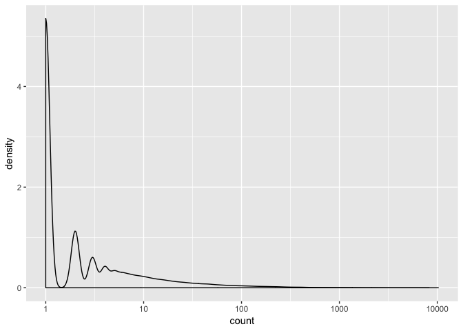

```r
##    0%   10%   20%   30%   40%   50%   60%   70%   80%   90%  100%
##     1     1     1     1     1     1     2     3     5    13 10253
library(ggplot2)                                # Note: 2
ggplot(data.frame(count=basketSizes)) +
  geom_density(aes(x=count)) +
  scale_x_log10()
```

```r
# Note 1:
#   Look at the basket size distribution, in 10%
#   increments.

# Note 2:
#   Plot the distribution to get a better
#   look.
```

00393_example_9.21_of_section_9.2.3.R

```r
# example 9.21 of section 9.2.3
# (example 9.21 of section 9.2.3)  : Unsupervised methods : Association rules : Mining association rules with the arules package
# Title: Count how often each book occurs

bookCount <- itemFrequency(bookbaskets, "absolute")
summary(bookCount)
```

```
##     Min.  1st Qu.   Median     Mean  3rd Qu.     Max.
##    1.000    1.000    1.000    4.638    3.000 2502.000
```

```r
##     Min.  1st Qu.   Median     Mean  3rd Qu.     Max.
##    1.000    1.000    1.000    4.638    3.000 2502.000
```

00394_example_9.22_of_section_9.2.3.R

```r
# example 9.22 of section 9.2.3
# (example 9.22 of section 9.2.3)  : Unsupervised methods : Association rules : Mining association rules with the arules package
# Title: Finding the ten most frequent books

orderedBooks <- sort(bookCount, decreasing=TRUE)    # Note: 1
knitr::kable(orderedBooks[1:10])                    # Note: 2
|                                                |    x|
|:-----------------------------------------------|----:|
|Wild Animus                                     | 2502|
|The Lovely Bones: A Novel                       | 1295|
|She's Come Undone                               |  934|
|The Da Vinci Code                               |  905|
|Harry Potter and the Sorcerer's Stone           |  832|
|The Nanny Diaries: A Novel                      |  821|
|A Painted House                                 |  819|
|Bridget Jones's Diary                           |  772|
|The Secret Life of Bees                         |  762|
|Divine Secrets of the Ya-Ya Sisterhood: A Novel |  737|

orderedBooks[1]/nrow(bookbaskets)                   # Note: 3
## Wild Animus
##  0.02716376

# Note 1:
#   Sort the counts in decreasing order.

# Note 2:
#   Display the top 10 books in a nice format

# Note 3:
#   The most popular book in the dataset
#   occurred in fewer than 3% of the baskets.
```

[output not shown]

00395_informalexample_9.11_of_section_9.2.3.R

```r
# informalexample 9.11 of section 9.2.3
# (informalexample 9.11 of section 9.2.3)  : Unsupervised methods : Association rules : Mining association rules with the arules package

bookbaskets_use <- bookbaskets[basketSizes > 1]
dim(bookbaskets_use)
```

```
## [1]  40822 220447
```

```r
## [1]  40822 220447
```

00396_example_9.23_of_section_9.2.3.R

```r
# example 9.23 of section 9.2.3
# (example 9.23 of section 9.2.3)  : Unsupervised methods : Association rules : Mining association rules with the arules package
# Title: Finding the association rules

rules <- apriori(bookbaskets_use,                                   # Note: 1
                parameter =list(support = 0.002, confidence=0.75))
```

```
## Apriori
##
## Parameter specification:
##  confidence minval smax arem  aval originalSupport maxtime support minlen
##        0.75    0.1    1 none FALSE            TRUE       5   0.002      1
##  maxlen target   ext
##      10  rules FALSE
##
## Algorithmic control:
##  filter tree heap memopt load sort verbose
##     0.1 TRUE TRUE  FALSE TRUE    2    TRUE
##
## Absolute minimum support count: 81
##
## set item appearances ...[0 item(s)] done [0.00s].
## set transactions ...[216031 item(s), 40822 transaction(s)] done [0.93s].
## sorting and recoding items ... [1256 item(s)] done [0.03s].
## creating transaction tree ... done [0.02s].
## checking subsets of size 1 2 3 4 5 done [0.04s].
## writing ... [191 rule(s)] done [0.00s].
## creating S4 object  ... done [0.06s].
```

```r
summary(rules)
```

```
## set of 191 rules
##
## rule length distribution (lhs + rhs):sizes
##   2   3   4   5
##  11 100  66  14
##
##    Min. 1st Qu.  Median    Mean 3rd Qu.    Max.
##   2.000   3.000   3.000   3.435   4.000   5.000
##
## summary of quality measures:
##     support           confidence          lift            count
##  Min.   :0.002009   Min.   :0.7500   Min.   : 40.89   Min.   : 82.0
##  1st Qu.:0.002131   1st Qu.:0.8113   1st Qu.: 86.44   1st Qu.: 87.0
##  Median :0.002278   Median :0.8468   Median :131.36   Median : 93.0
##  Mean   :0.002593   Mean   :0.8569   Mean   :129.68   Mean   :105.8
##  3rd Qu.:0.002695   3rd Qu.:0.9065   3rd Qu.:158.77   3rd Qu.:110.0
##  Max.   :0.005830   Max.   :0.9882   Max.   :321.89   Max.   :238.0
##
## mining info:
##             data ntransactions support confidence
##  bookbaskets_use         40822   0.002       0.75
```

```r
## set of 191 rules     # Note: 2
##
## rule length distribution (lhs + rhs):sizes       # Note: 3
##   2   3   4   5
##  11 100  66  14
##
##    Min. 1st Qu.  Median    Mean 3rd Qu.    Max.
##   2.000   3.000   3.000   3.435   4.000   5.000
##
## summary of quality measures:                     # Note: 4
##     support           confidence          lift            count
##  Min.   :0.002009   Min.   :0.7500   Min.   : 40.89   Min.   : 82.0
##  1st Qu.:0.002131   1st Qu.:0.8113   1st Qu.: 86.44   1st Qu.: 87.0
##  Median :0.002278   Median :0.8468   Median :131.36   Median : 93.0
##  Mean   :0.002593   Mean   :0.8569   Mean   :129.68   Mean   :105.8
##  3rd Qu.:0.002695   3rd Qu.:0.9065   3rd Qu.:158.77   3rd Qu.:110.0
##  Max.   :0.005830   Max.   :0.9882   Max.   :321.89   Max.   :238.0
##
## mining info:                                         # Note: 5
##             data ntransactions support confidence
##  bookbaskets_use         40822   0.002       0.75

# Note 1:
#   Call apriori() with a minimum support of
#   0.002 and a minimum confidence of 0.75.

# Note 2:
#   The summary of the apriori() output reports
#   the number of rules found;...

# Note 3:
#   ...the distribution of rule lengths (in this
#   example, most rules contain 3 items—2 on the left
#   side, X (lhs), and one on the right side, Y
#   (rhs));...

# Note 4:
#   ...a summary of rule quality measures,
#   including support and confidence;...

# Note 5:
#   ...and some information on how apriori() was
#   called.
```

00397_example_9.24_of_section_9.2.3.R

```r
# example 9.24 of section 9.2.3
# (example 9.24 of section 9.2.3)  : Unsupervised methods : Association rules : Mining association rules with the arules package
# Title: Scoring rules

measures <- interestMeasure(rules,                              # Note: 1
                 measure=c("coverage", "fishersExactTest"),     # Note: 2
                 transactions=bookbaskets_use)                  # Note: 3
summary(measures)
```

```
##     coverage        fishersExactTest
##  Min.   :0.002082   Min.   : 0.000e+00
##  1st Qu.:0.002511   1st Qu.: 0.000e+00
##  Median :0.002719   Median : 0.000e+00
##  Mean   :0.003039   Mean   :5.080e-138
##  3rd Qu.:0.003160   3rd Qu.: 0.000e+00
##  Max.   :0.006982   Max.   :9.702e-136
```

```r
##     coverage        fishersExactTest
##  Min.   :0.002082   Min.   : 0.000e+00
##  1st Qu.:0.002511   1st Qu.: 0.000e+00
##  Median :0.002719   Median : 0.000e+00
##  Mean   :0.003039   Mean   :5.080e-138
##  3rd Qu.:0.003160   3rd Qu.: 0.000e+00
##  Max.   :0.006982   Max.   :9.702e-136

# Note 1:
#   The call to interestMeasure() takes as
#   arguments the discovered rules,...

# Note 2:
#   ...a list of interest measures to
#   apply,...

# Note 3:
#   ...and a dataset to evaluate the interest
#   measures over. This is usually the same set used
#   to mine the rules, but it needn’t be. For
#   instance, you can evaluate the rules over the full
#   dataset, bookbaskets, to get coverage estimates
#   that reflect all the customers, not just the ones
#   who showed interest in more than one book.
```

00398_example_9.25_of_section_9.2.3.R

```r
# example 9.25 of section 9.2.3
# (example 9.25 of section 9.2.3)  : Unsupervised methods : Association rules : Mining association rules with the arules package
# Title: Get the five most confident rules

library(magrittr)                           # Note: 1

rules %>%
  sort(., by="confidence") %>%              # Note: 2
  head(., n=5) %>%                          # Note: 3
  inspect(.)                                # Note: 4
```

```
##     lhs                                               rhs                                                support confidence      lift count
## [1] {Four to Score,
##      High Five,
##      Seven Up,
##      Two for the Dough}                            => {Three To Get Deadly : A Stephanie Plum Novel} 0.002057714  0.9882353 165.33500    84
## [2] {Harry Potter and the Order of the Phoenix,
##      Harry Potter and the Prisoner of Azkaban,
##      Harry Potter and the Sorcerer's Stone}        => {Harry Potter and the Chamber of Secrets}      0.002866102  0.9669421  72.82751   117
## [3] {Four to Score,
##      High Five,
##      One for the Money,
##      Two for the Dough}                            => {Three To Get Deadly : A Stephanie Plum Novel} 0.002082211  0.9659091 161.59976    85
## [4] {Four to Score,
##      Seven Up,
##      Three To Get Deadly : A Stephanie Plum Novel,
##      Two for the Dough}                            => {High Five}                                    0.002057714  0.9655172 180.79975    84
## [5] {High Five,
##      Seven Up,
##      Three To Get Deadly : A Stephanie Plum Novel,
##      Two for the Dough}                            => {Four to Score}                                0.002057714  0.9655172 167.72062    84
```

```r
# Note 1:
#   Attach magrittr to get pipe notation.

# Note 2:
#   Sort rules by confidence.

# Note 3:
#   Get the first 5 rules.

# Note 4:
#   Call inspect() to pretty-print the rules.
```

00399_example_9.26_of_section_9.2.3.R

```r
# example 9.26 of section 9.2.3
# (example 9.26 of section 9.2.3)  : Unsupervised methods : Association rules : Mining association rules with the arules package
# Title: Finding rules with restrictions

brules <- apriori(bookbaskets_use,
                parameter =list(support = 0.001,        # Note: 1
                                confidence=0.6),
                appearance=list(rhs=c("The Lovely Bones: A Novel"),     # Note: 2
                                default="lhs"))                         # Note: 3
```

```
## Apriori
##
## Parameter specification:
##  confidence minval smax arem  aval originalSupport maxtime support minlen
##         0.6    0.1    1 none FALSE            TRUE       5   0.001      1
##  maxlen target   ext
##      10  rules FALSE
##
## Algorithmic control:
##  filter tree heap memopt load sort verbose
##     0.1 TRUE TRUE  FALSE TRUE    2    TRUE
##
## Absolute minimum support count: 40
##
## set item appearances ...[1 item(s)] done [0.00s].
## set transactions ...[216031 item(s), 40822 transaction(s)] done [0.84s].
## sorting and recoding items ... [3172 item(s)] done [0.03s].
## creating transaction tree ... done [0.02s].
## checking subsets of size 1 2 3 4 5 6 7 8 done [0.21s].
## writing ... [46 rule(s)] done [0.04s].
## creating S4 object  ... done [0.06s].
```

```r
summary(brules)
```

```
## set of 46 rules
##
## rule length distribution (lhs + rhs):sizes
##  3  4
## 44  2
##
##    Min. 1st Qu.  Median    Mean 3rd Qu.    Max.
##   3.000   3.000   3.000   3.043   3.000   4.000
##
## summary of quality measures:
##     support           confidence          lift           count
##  Min.   :0.001004   Min.   :0.6000   Min.   :21.81   Min.   :41.00
##  1st Qu.:0.001029   1st Qu.:0.6118   1st Qu.:22.24   1st Qu.:42.00
##  Median :0.001102   Median :0.6258   Median :22.75   Median :45.00
##  Mean   :0.001132   Mean   :0.6365   Mean   :23.14   Mean   :46.22
##  3rd Qu.:0.001219   3rd Qu.:0.6457   3rd Qu.:23.47   3rd Qu.:49.75
##  Max.   :0.001396   Max.   :0.7455   Max.   :27.10   Max.   :57.00
##
## mining info:
##             data ntransactions support confidence
##  bookbaskets_use         40822   0.001        0.6
```

```r
## set of 46 rules
##
## rule length distribution (lhs + rhs):sizes
##  3  4
## 44  2
##
##    Min. 1st Qu.  Median    Mean 3rd Qu.    Max.
##   3.000   3.000   3.000   3.043   3.000   4.000
##
## summary of quality measures:
##     support           confidence          lift           count
##  Min.   :0.001004   Min.   :0.6000   Min.   :21.81   Min.   :41.00
##  1st Qu.:0.001029   1st Qu.:0.6118   1st Qu.:22.24   1st Qu.:42.00
##  Median :0.001102   Median :0.6258   Median :22.75   Median :45.00
##  Mean   :0.001132   Mean   :0.6365   Mean   :23.14   Mean   :46.22
##  3rd Qu.:0.001219   3rd Qu.:0.6457   3rd Qu.:23.47   3rd Qu.:49.75
##  Max.   :0.001396   Max.   :0.7455   Max.   :27.10   Max.   :57.00
##
## mining info:
##             data ntransactions support confidence
##  bookbaskets_use         40822   0.001        0.6

# Note 1:
#   Relax the minimum support to 0.001 and the
#   minimum confidence to 0.6.

# Note 2:
#   Only The Lovely Bones
#   is allowed to appear on the right side of the
#   rules.

# Note 3:
#   By default, all the books can go into the
#   left side of the rules.
```

00400_example_9.27_of_section_9.2.3.R

```r
# example 9.27 of section 9.2.3
# (example 9.27 of section 9.2.3)  : Unsupervised methods : Association rules : Mining association rules with the arules package
# Title: Inspecting rules

brules %>%
  sort(., by="confidence") %>%
  lhs(.) %>%                # Note: 1
  head(., n=5) %>%
  inspect(.)
```

```
##     items
## [1] {Divine Secrets of the Ya-Ya Sisterhood: A Novel,
##      Lucky : A Memoir}
## [2] {Lucky : A Memoir,
##      The Notebook}
## [3] {Lucky : A Memoir,
##      Wild Animus}
## [4] {Midwives: A Novel,
##      Wicked: The Life and Times of the Wicked Witch of the West}
## [5] {Lucky : A Memoir,
##      Summer Sisters}
```

```r
##   items
## 1 {Divine Secrets of the Ya-Ya Sisterhood: A Novel,
##    Lucky : A Memoir}
## 2 {Lucky : A Memoir,
##    The Notebook}
## 3 {Lucky : A Memoir,
##    Wild Animus}
## 4 {Midwives: A Novel,
##    Wicked: The Life and Times of the Wicked Witch of the West}
## 5 {Lucky : A Memoir,
##    Summer Sisters}

# Note 1:
#   Get the left hand side of the sorted rules.
```

00401_example_9.28_of_section_9.2.3.R

```r
# example 9.28 of section 9.2.3
# (example 9.28 of section 9.2.3)  : Unsupervised methods : Association rules : Mining association rules with the arules package
# Title: Inspecting rules with restrictions

brulesSub <- subset(brules, subset=!(lhs %in% "Lucky : A Memoir"))      # Note: 1
brulesSub %>%
  sort(., by="confidence") %>%
  lhs(.) %>%
  head(., n=5) %>%
  inspect(.)
```

```
##     items
## [1] {Midwives: A Novel,
##      Wicked: The Life and Times of the Wicked Witch of the West}
## [2] {She's Come Undone,
##      The Secret Life of Bees,
##      Wild Animus}
## [3] {A Walk to Remember,
##      The Nanny Diaries: A Novel}
## [4] {Beloved,
##      The Red Tent}
## [5] {The Da Vinci Code,
##      The Reader}
```

```r
brulesConf <- sort(brulesSub, by="confidence")

inspect(head(lhs(brulesConf), n=5))
```

```
##     items
## [1] {Midwives: A Novel,
##      Wicked: The Life and Times of the Wicked Witch of the West}
## [2] {She's Come Undone,
##      The Secret Life of Bees,
##      Wild Animus}
## [3] {A Walk to Remember,
##      The Nanny Diaries: A Novel}
## [4] {Beloved,
##      The Red Tent}
## [5] {The Da Vinci Code,
##      The Reader}
```

```r
##   items
## 1 {Midwives: A Novel,
##    Wicked: The Life and Times of the Wicked Witch of the West}
## 2 {She's Come Undone,
##    The Secret Life of Bees,
##    Wild Animus}
## 3 {A Walk to Remember,
##    The Nanny Diaries: A Novel}
## 4 {Beloved,
##    The Red Tent}
## 5 {The Da Vinci Code,
##    The Reader}

# Note 1:
#   Restrict to the subset of rules where
#   Lucky is not in the left
#   side.
```